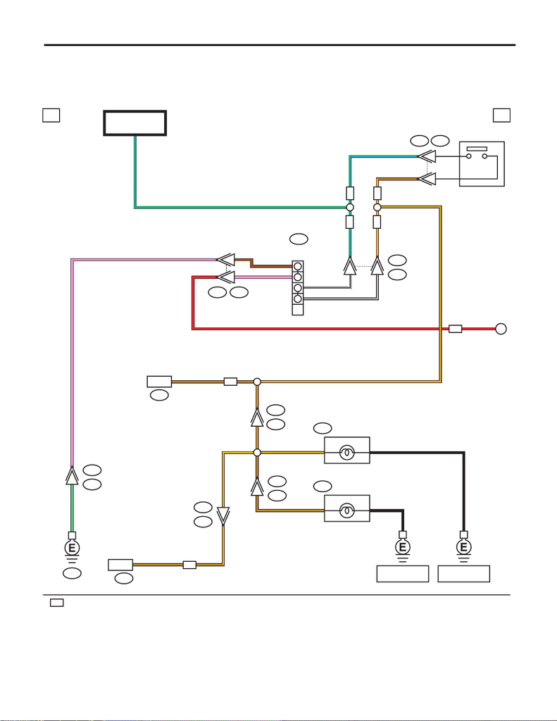

WI-104

Back-up Light System

WIRING SYSTEM

9. Back-up Light System

A: WIRING DIAGRAM

1. ENGINE TYPE FA

WI-44304

1a 1a

T7

i87

C:

MT

MT

CVT

CVT

MT

WN

WN

i53

R98

R28

R26

B12 T3

R

T3

B12

GT

T1B24

B281

B:

2

1

9

10

R81

R82

5

T4

B11

R1

B97

13

4

2

1

4

W/B

7

5PR

P

1BR

B/W

8

C2 BR/Y

BR/Y

BR/Y

B

B

1

1

2

2

BR/Y

G/L

B12 BR/Y

BR/Y

BR/Y

G/W P

BR/Y

BR/Y BR/Y BR/Y

B

BR/Y

G/L

B

G/L

CVT

R

A

BODY INTEGRATED

UNIT

BACK-UP LIGHT

SWITCH

FB-35

F/B FUSE NO. 18

(IG)

NAVIGATION

UNIT

REAR COMBINATION

LIGHT RH

BACK-UP LIGHT

BACK-UP LIGHT

REAR COMBINATION

LIGHT LH

INHIBITOR

SWITCH

: WITH NAVIGATION

REF. TO GND [h]REF. TO GND [f]

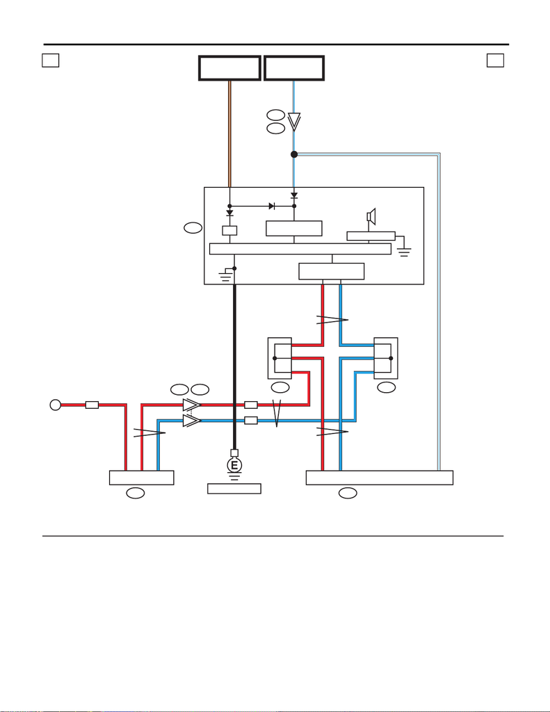

WI-105

Back-up Light System

WIRING SYSTEM

WI-44305

3

1b 1b

i84

C:

B54

i229

B551

I/F

i10

38

20

33

32L

R

B

BR/W

40 W/L

BR/W

B

C35

C6

C27

W/L

L

44 L

43 R

37 R

RR

L

R

W/LW/L

i233i232

1

1

1

1

1

1

1

CVT

A

CVT

CVT

6

7

i229B551

FB-18

F/B FUSE NO. 7

(B)

SPEAKER

DRIVE CIRCUIT

POWER SUPPLY

CIRCUIT

FB-12

F/B FUSE NO. 2

(IG)

CAN TRANSCEIVER &

RECEIVER

MICRO COMPUTER

COMBINATION

METER

REF. TO GND [e]

BODY INTEGRATED UNITTCM

J/CJ/C

: TERMINAL No. OPTIONAL ARRANGEMENT

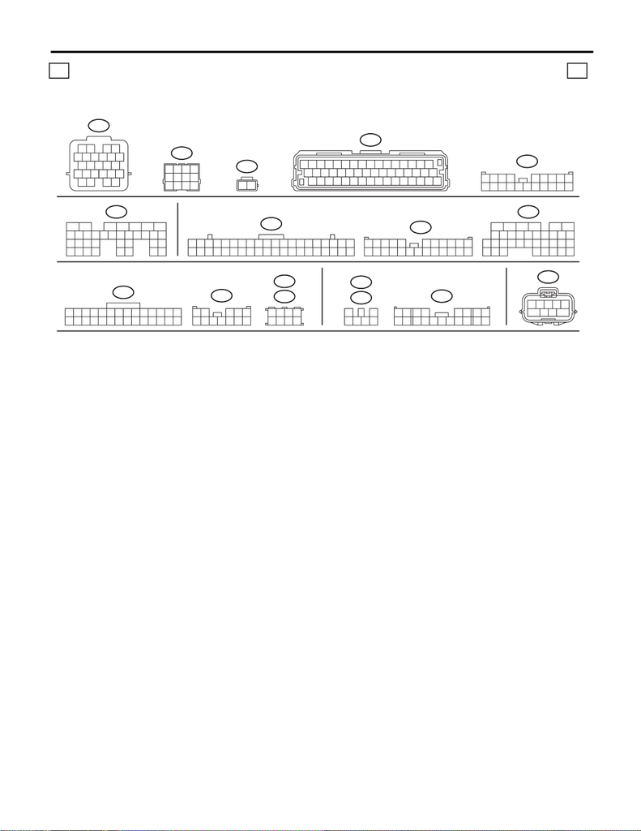

WI-106

Back-up Light System

WIRING SYSTEM

i233

i232

78

5

6

34

21

WI-44306

1c 1c

(B)

B12

5

9

1

6

10

2

7

11

3

8

12

4

(GR)

B24

(B)

B54

B97

21

123456789

10 11 12 13 14 15 16

17 18 19 20 21 22 23 24 25 26 27 28 29 30 31 32

33 34 35 36 37 38 39 40 41 42 43 44 45 46 47 48

89

19 20

1234 567

10 11 12 13 14 15 16 17 18

i10

11 12

9

10

7856341

2

15 1613 14 19

18

20

21 22 23 24 26

25

27 28 29 30 31 32 33 34 35 36 37 38 39 40

17 19

18

21

20

2322 24 25 26

17

1

23

4

56

27

28 29 30

31 32 33 34 35

798

151413121110 16

i84C:

123456789

15 16 17 18 19 20 21 22 23 24

10 11 12 13 14

25 26 27 28

i87C:

5

6

34

21

R28

(B)

T7

i53

(B)

R82

R26

1

78

69

2345

3412 89

10 11

12 13 14 15 16 17 18 19 20 21 22 23 24

567

1

9

234 5678

10 11 12 14 15 16 17 18 1913

i229

12 345

6789

10 11 12

B11

(GR)

567

12 34

9

10 11 12

17 18 19 20

8

13 14 15 16

B281B:

5672134

29

10 11 12 13 14 15

2524

16

30

98

17 18 19

20

28

21 22 23

3231

26 27

33 34 35

LIST OF CONNECTORS

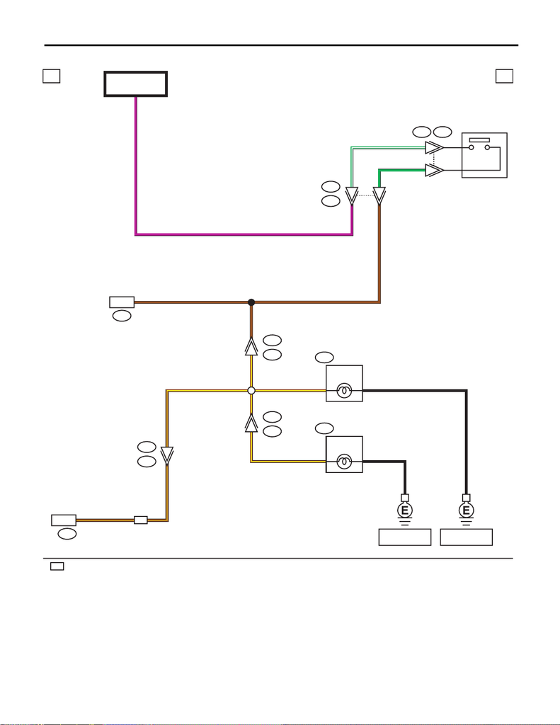

WI-107

Back-up Light System

WIRING SYSTEM

2. ENGINE TYPE EJ

WI-44307

2a 2a

i87

C:

WN

WN

i53

R98

R28

R26

B128

T9

T1T13

B281

B:

1

2

3

R81

R82

5

R1

B97

4

6

1

C2 BR/Y

BR/Y

BR/Y

B

B

1

1

2

2

G

G/W

B12 BR

BR/Y

BR/Y BR/Y

BR

BR/Y BR/Y BR

B

B

V

V

BODY INTEGRATED

UNIT

BACK-UP LIGHT

SWITCH

FB-35

F/B FUSE NO. 18

(IG)

NAVIGATION

UNIT

REAR COMBINATION

LIGHT RH

BACK-UP

LIGHT

BACK-UP

LIGHT

REAR COMBINATION

LIGHT LH

: WITH NAVIGATION

REF. TO GND [h]REF. TO GND [f]

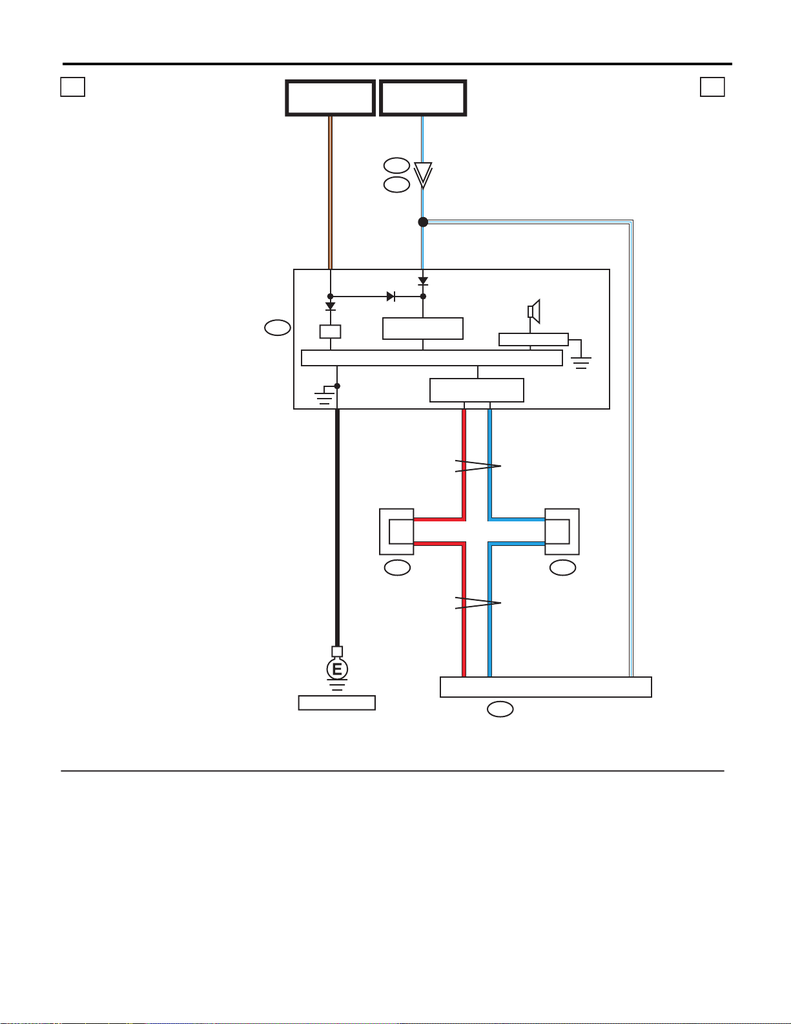

WI-108

Back-up Light System

WIRING SYSTEM

WI-44308

3

2b 2b

i84

C:

i229

B551

I/F

i10

38

20

33

32L

R

B

BR/W

40 W/L

BR/W

B

C35

C6

C27

W/L

L

R

W/LW/L

1

1

1

1

1

i233i232

FB-18

F/B FUSE NO. 7

(B)

SPEAKER

DRIVE CIRCUIT

POWER SUPPLY

CIRCUIT

FB-12

F/B FUSE NO. 2

(IG)

CAN TRANSCEIVER &

RECEIVER

MICRO COMPUTER

COMBINATION

METER

REF. TO GND [e]

BODY INTEGRATED UNIT

: TERMINAL No. OPTIONAL ARRANGEMENT

J/CJ/C

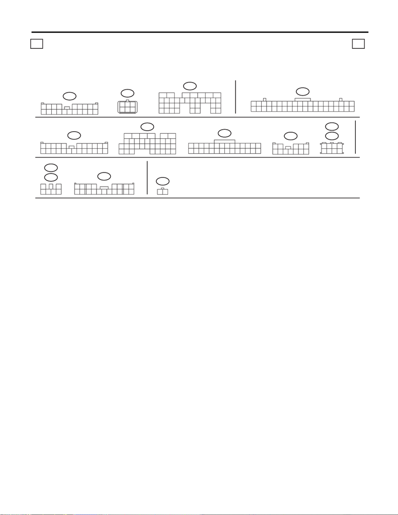

WI-109

Back-up Light System

WIRING SYSTEM

i233

i232

78

5

6

34

21

WI-44309

2c 2c

i10

11 12

9

10

7856341

2

15 1613 14 19

18

20

21 22 23 24 26

25

27 28 29 30 31 32 33 34 35 36 37 38 39 40

17

19

18

21

20

2322 24 25 26

17

1

23

4

56

27

28 29 30

31 32 33 34 35

798

151413121110 16

i84C:

123456789

15 16 17 18 19 20 21 22 23 24

10 11 12 13 14

25 26 27 28

i87C:

i53

3412 89

10 11

12 13 14 15 16 17 18 19 20 21 22 23 24

567

i229

12 345

6789

10 11 12

B281B:

5672134

29

10 11 12 13 14 15

2524

16

30

98

17 18 19

20

28

21 22 23

3231

26 27

33 34 35

123

456

B128

(GR)

(B)

R82

1

9

234 5678

10 11 12 14 15 16 17 18 1913

89

19 20

1234 567

10 11 12 13 14 15 16 17 18

B97

5

6

34

21

R28

R26

12

T1

(GR)

LIST OF CONNECTORS